# Student 3000 Criminal Data : ggplot

coop711

## Working Data Loading

```r
load("./crimtab.RData")
ls()
```

```
## [1] "crimtab.2"       "crimtab.df"      "crimtab.long"    "crimtab.long.df"
```

```r
ls.str()
```

```
## crimtab.2 :  'table' int [1:42, 1:22] 0 0 0 0 0 0 1 0 0 0 ...
## crimtab.df : 'data.frame':   924 obs. of  3 variables:
##  $ finger: num  9.4 9.5 9.6 9.7 9.8 9.9 10 10.1 10.2 10.3 ...
##  $ height: num  56 56 56 56 56 56 56 56 56 56 ...
##  $ Freq  : int  0 0 0 0 0 0 1 0 0 0 ...
## crimtab.long :  num [1:3000, 1:2] 10 10.3 9.9 10.2 10.2 10.3 10.4 10.7 10 10.1 ...
## crimtab.long.df : 'data.frame':  3000 obs. of  2 variables:
##  $ finger: num  10 10.3 9.9 10.2 10.2 10.3 10.4 10.7 10 10.1 ...
##  $ height: num  56 57 58 58 58 58 58 58 59 59 ...
```

```r
head(crimtab.long.df)
```

```
##   finger height
## 1   10.0     56
## 2   10.3     57
## 3    9.9     58
## 4   10.2     58
## 5   10.2     58
## 6   10.3     58
```

## Graphic Representation

### Base Graphics

- 키와 손가락길이의 산점도

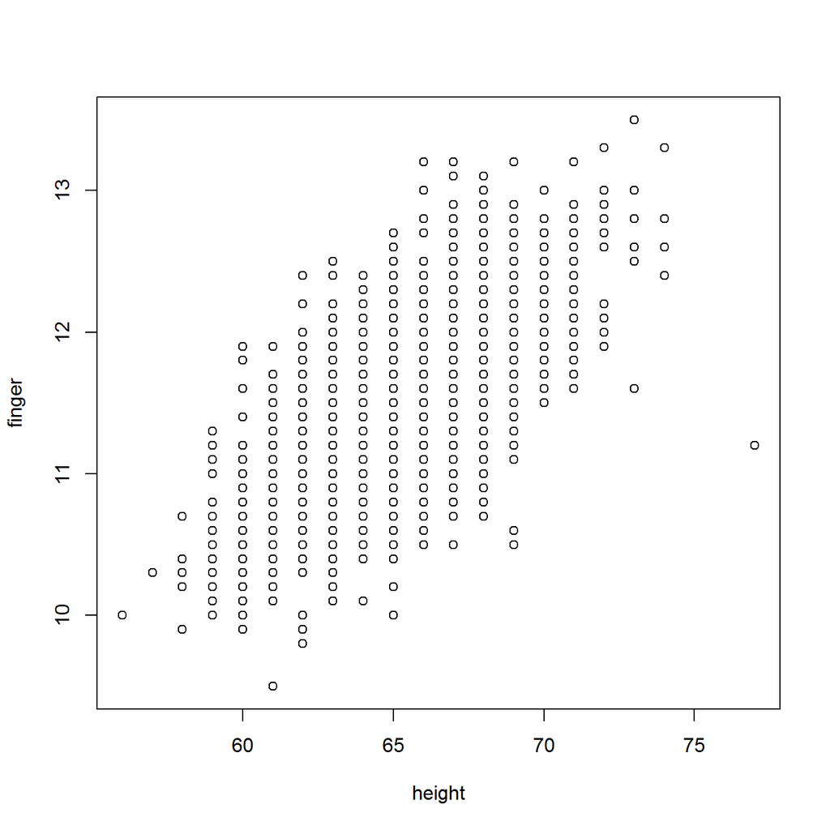

```r
# plot(finger ~ height, data = crimtab.long.df)
plot(crimtab.long.df[2:1])
```

- 변수 각각의 히스토그램은?

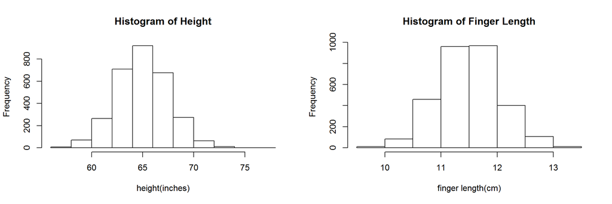

```r
par(mfrow = c(1, 2))
hist(crimtab.long.df$height, main = "Histogram of Height", xlab = "height(inches)")
hist(crimtab.long.df$finger, main = "Histogram of Finger Length", xlab = "finger length(cm)")
```

```r
# hist(crimtab.long.df["height"], main="Histogram of Height", xlab="height(inches)")
# hist(crimtab.long.df["finger"], main="Histogram of Finger Length", xlab= "finger length(cm)")
```

- 평균과 표준편차를 한번에 구하려면 다음과 같이 anonymous function을 작성하고 `mapply()` 또는 `sapply()`를 이용하는 게 편함. 이를 모수로 하는 정규곡선을 덧씌워 볼 것.
  - `mean_sd()`도 `anonymous function` 으로 평균과 표준편차를 계산해서 출력하는 함수임. 이와 같은 함수를 저장해 놓으려면 `dump()`를 이용함.
  - 이와 같이 계산한 평균과 표준편차를 모수로 하는 정규곡선을 덧씌워 볼 것.

```r
mean_sd <- function(x) {
  mean <- mean(x, na.rm = TRUE)
  sd <- sd(x)
  return(c(mean = mean, sd = sd))
# list(mean = mean, sd = sd)
}
dump("mean_sd", file = "mean_sd.R")
```

```r
crimtab.stat <- sapply(crimtab.long.df, mean_sd)
# crimtab.stat <- mapply(mean_sd, crimtab.long.df)
# apply(crimtab.long, 2, mean)
# apply(crimtab.long, 2, sd)
str(crimtab.stat)
```

```
##  num [1:2, 1:2] 11.547 0.549 65.473 2.558
##  - attr(*, "dimnames")=List of 2
##   ..$ : chr [1:2] "mean" "sd"
##   ..$ : chr [1:2] "finger" "height"
```

- `crimtab.stat`이 어떤 성격을 갖는지 다음 질문과 추출 작업을 통해서 알아보자.

```r
is.matrix(crimtab.stat)
```

```
## [1] TRUE
```

```r
is.table(crimtab.stat)
```

```
## [1] FALSE
```

```r
is.list(crimtab.stat)
```

```
## [1] FALSE
```

```r
is.data.frame(crimtab.stat)
```

```
## [1] FALSE
```

```r
crimtab.stat[, 1]
```

```
##       mean         sd
## 11.5473667  0.5487137
```

```r
crimtab.stat[, "finger"]
```

```
##       mean         sd
## 11.5473667  0.5487137
```

```r
crimtab.stat[, "finger"][1]
```

```
##     mean
## 11.54737
```

```r
crimtab.stat[, "finger"][[1]]
```

```
## [1] 11.54737
```

```r
crimtab.stat[1]
```

```
## [1] 11.54737
```

```r
crimtab.stat[2:3]
```

```
## [1]  0.5487137 65.4730000
```

```r
# crimtab.stat["finger"]
# crimtab.stat$finger
```

matrix 를 data frame 으로 변환하면

```r
(crimtab.stat.df <- data.frame(crimtab.stat))
```

```
##          finger    height
## mean 11.5473667 65.473000
## sd    0.5487137  2.557757
```

```r
is.matrix(crimtab.stat.df)
```

```
## [1] FALSE
```

```r
is.table(crimtab.stat.df)
```

```
## [1] FALSE
```

```r
is.list(crimtab.stat.df)
```

```
## [1] TRUE
```

```r
is.data.frame(crimtab.stat.df)
```

```
## [1] TRUE
```

```r
crimtab.stat.df[, 1]
```

```
## [1] 11.5473667  0.5487137
```

```r
str(crimtab.stat.df[, 1])
```

```
##  num [1:2] 11.547 0.549
```

```r
crimtab.stat.df[, "finger"]
```

```
## [1] 11.5473667  0.5487137
```

```r
str(crimtab.stat.df[, "finger"])
```

```
##  num [1:2] 11.547 0.549
```

```r
crimtab.stat.df[, "finger"][1]
```

```
## [1] 11.54737
```

```r
str(crimtab.stat.df[, "finger"][1])
```

```
##  num 11.5
```

```r
crimtab.stat.df[, "finger"][[1]]
```

```
## [1] 11.54737
```

```r
str(crimtab.stat.df[, "finger"][[1]])
```

```
##  num 11.5
```

```r
crimtab.stat.df[1]
```

```
##          finger
## mean 11.5473667
## sd    0.5487137
```

```r
str(crimtab.stat.df[1])
```

```
## 'data.frame':    2 obs. of  1 variable:
##  $ finger: num  11.547 0.549
```

```r
crimtab.stat.df["finger"]
```

```
##          finger
## mean 11.5473667
## sd    0.5487137
```

```r
str(crimtab.stat.df["finger"])
```

```
## 'data.frame':    2 obs. of  1 variable:
##  $ finger: num  11.547 0.549
```

```r
crimtab.stat.df["finger"][1]
```

```
##          finger
## mean 11.5473667
## sd    0.5487137
```

```r
str(crimtab.stat.df["finger"][1])
```

```
## 'data.frame':    2 obs. of  1 variable:
##  $ finger: num  11.547 0.549
```

```r
crimtab.stat.df["finger"][[1]]
```

```
## [1] 11.5473667  0.5487137
```

```r
str(crimtab.stat.df["finger"][[1]])
```

```
##  num [1:2] 11.547 0.549
```

```r
crimtab.stat.df$finger
```

```
## [1] 11.5473667  0.5487137
```

```r
str(crimtab.stat.df$finger)
```

```
##  num [1:2] 11.547 0.549
```

```r
crimtab.stat.df$finger[1]
```

```
## [1] 11.54737
```

```r
str(crimtab.stat.df$finger[1])
```

```
##  num 11.5
```

```r
crimtab.stat.df$finger[[1]]
```

```
## [1] 11.54737
```

```r
str(crimtab.stat.df$finger[[1]])
```

```
##  num 11.5
```

### ggplot

- 키와 손가락 길이의 산점도

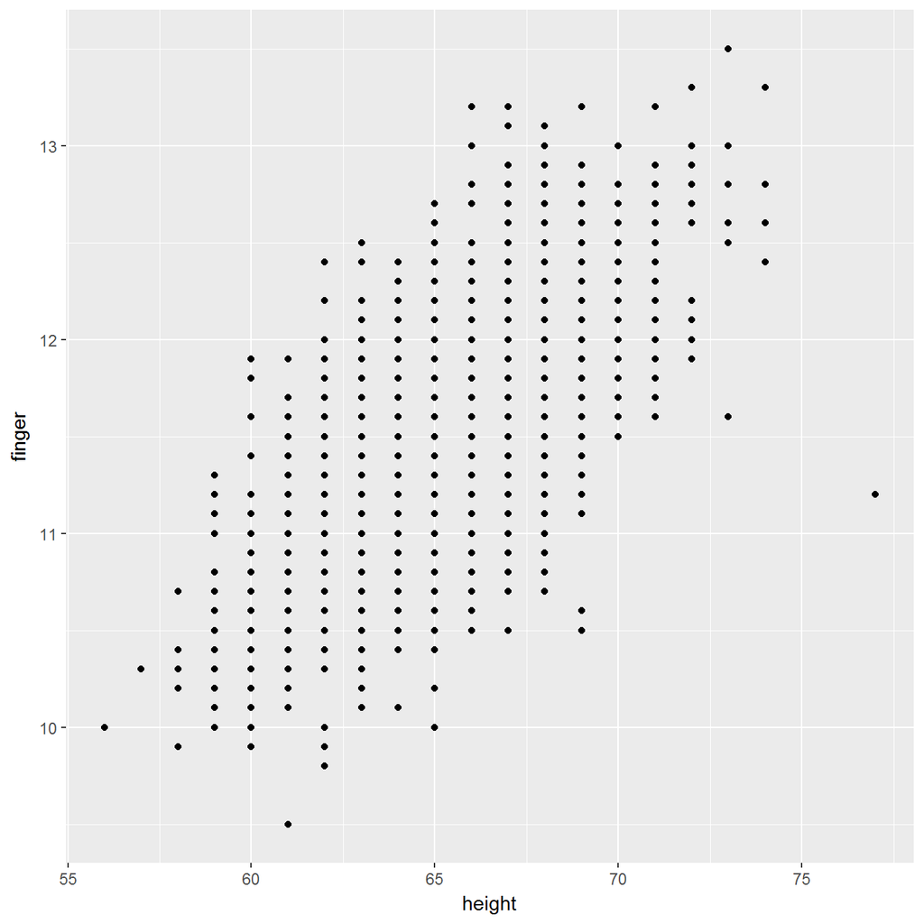

```r
library(ggplot2)
g1 <- ggplot(data = crimtab.long.df, mapping = aes(x = height, y = finger))
g2 <- g1 + geom_point()
g2
```

- 투명도 변경 : `alpha = 0.9`

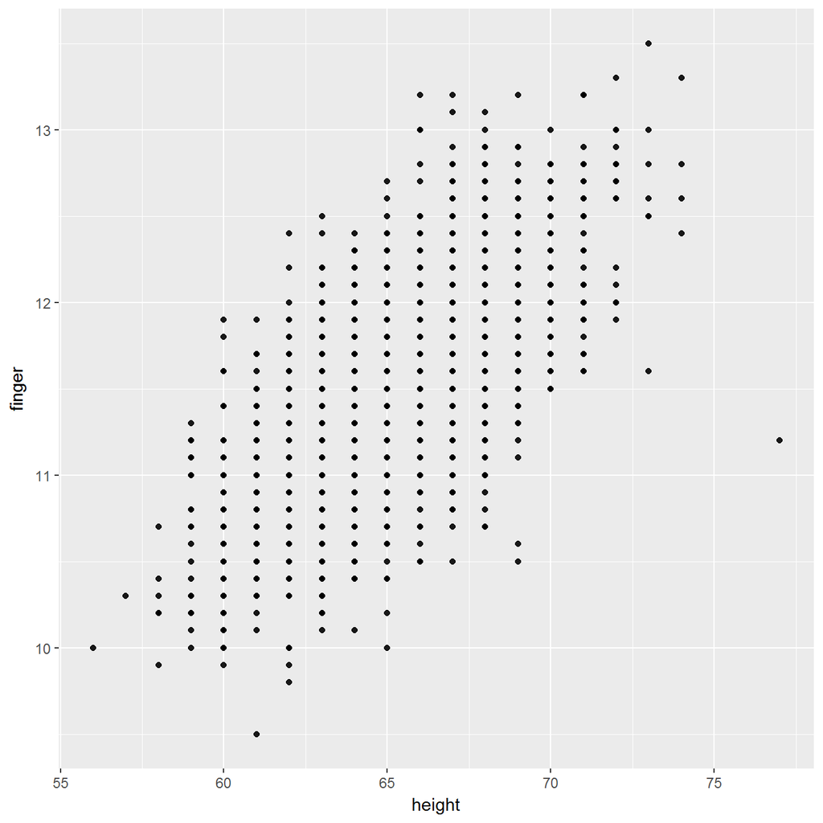

```r
g2.2 <- g1 + geom_point(alpha = 0.9)
g2.2
```

- 투명도 변경 : `alpha = 0.5`

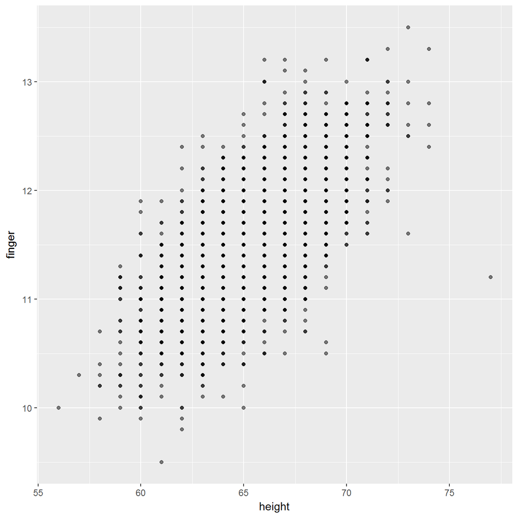

```r
g2.3 <- g1 + geom_point(alpha = 0.5)
g2.3
```

- 투명도 변경 : `alpha = 0.1`

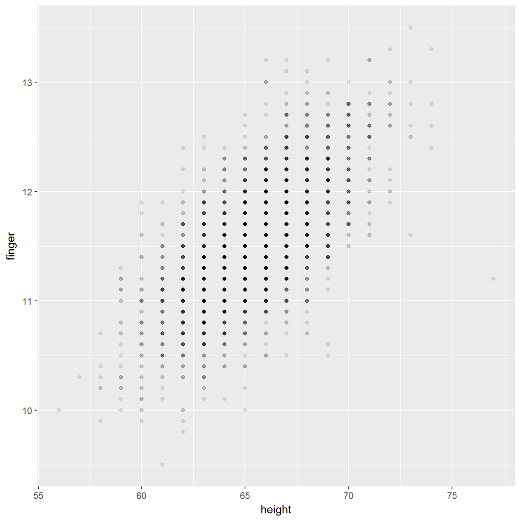

```r
g2.4 <- g1 + geom_point(alpha = 0.1)
g2.4
```

- 중복점 흐트러놓기 : `position = jitter`

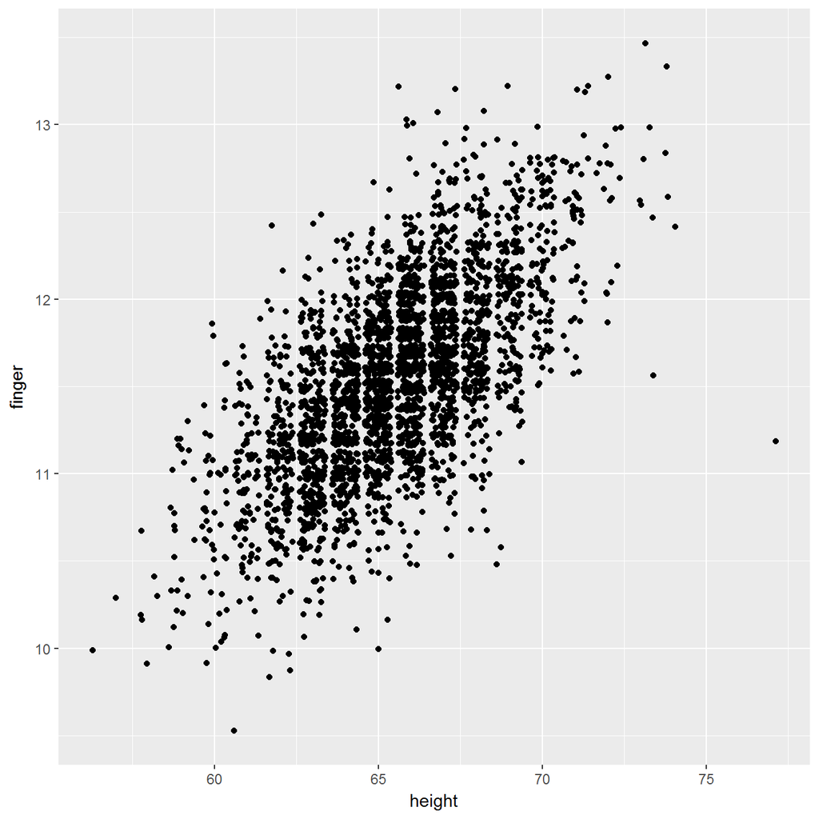

```r
g2.5 <- g1 + geom_point(position = "jitter")
g2.5
```

- 점의 크기를 줄이고 중복점 흐트러놓기 : `position = jitter, size = 0.7`

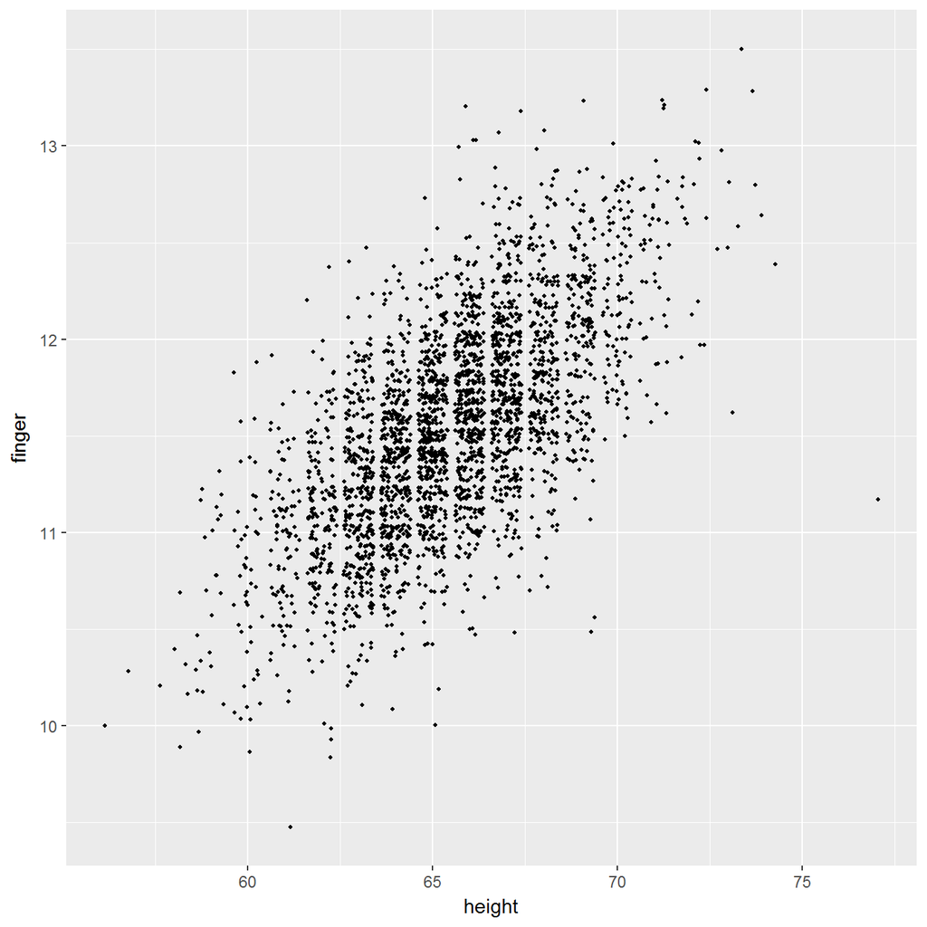

```r
g2.6 <- g1 + geom_point(position = "jitter", size = 0.7)
g2.6
```

- 동일한 효과 : `position = position_jitter(), size = 0.7`

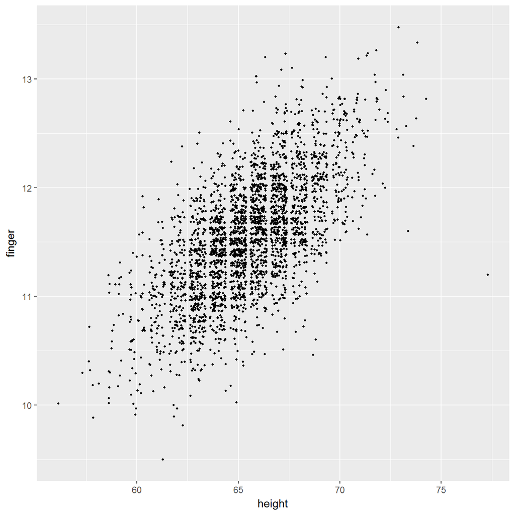

```r
g2.7 <- g1 + geom_point(position = position_jitter(), size = 0.7)
g2.7
```

- 흐트러놓는 폭 조절 : `width = 1, height = 0, size = 0.7`

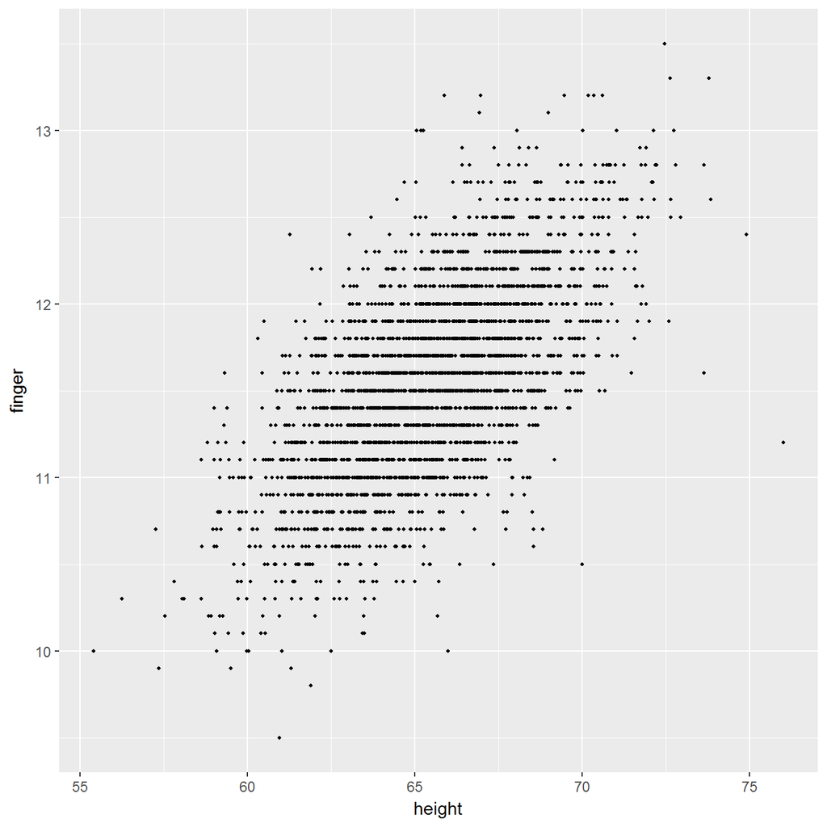

```r
g2.8 <- g1 + geom_point(position = position_jitter(width = 1, height = 0), size = 0.7)
g2.8
```

- 흐트러놓는 폭과 높이 조절 : `width = 1, height = 0.1, size = 0.7`

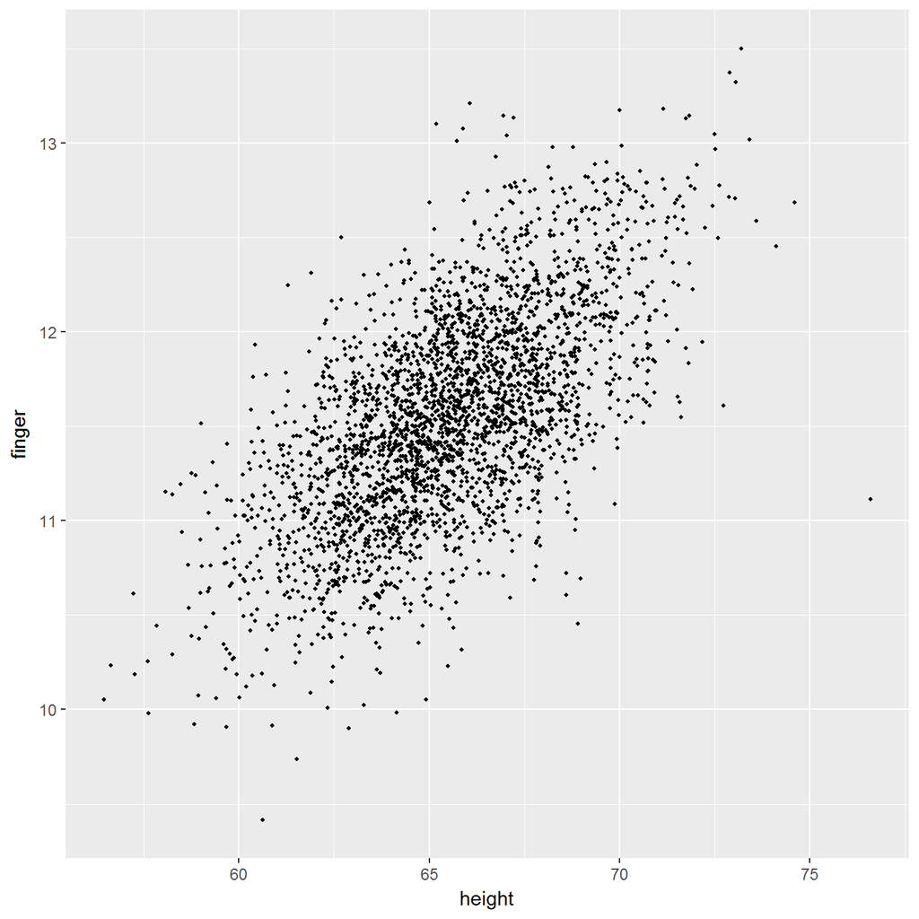

```r
g2.9 <- g1 + geom_point(position = position_jitter(width = 1, height = 0.1), size = 0.7)
g2.9
```

- 흑백 테마 : `theme_bw()`

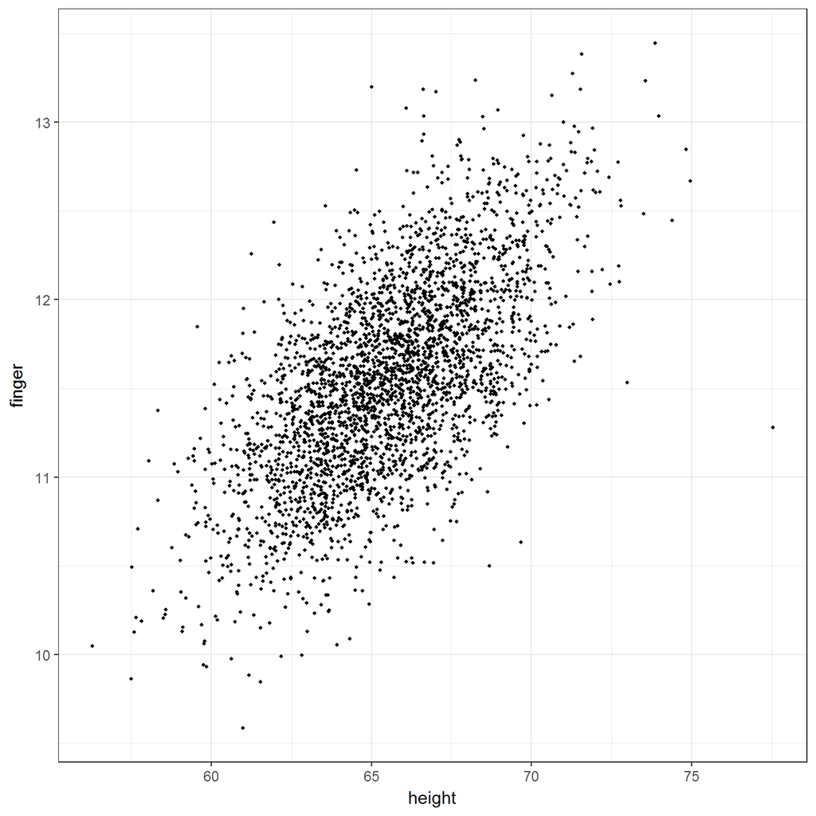

```r
g3 <- g2.9 +
  theme_bw()
g3
```

### 히스토그램

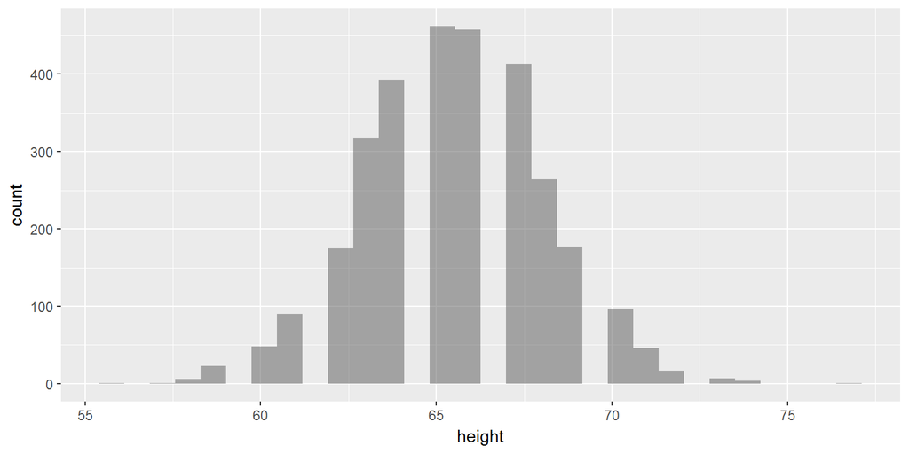

```r
h1 <- ggplot(data = crimtab.long.df, aes(x = height))
h1 + geom_histogram(alpha = 0.5)
```

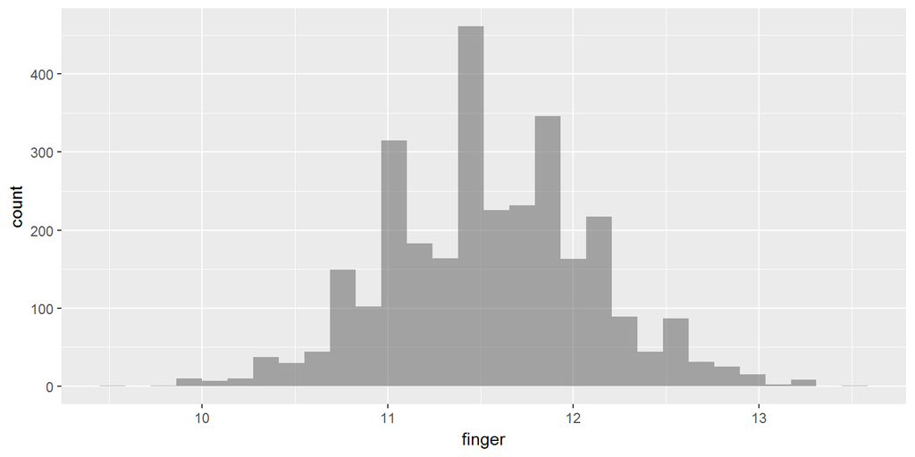

```r
f1 <- ggplot(data = crimtab.long.df, aes(x = finger))
f1 + geom_histogram(alpha = 0.5)
```

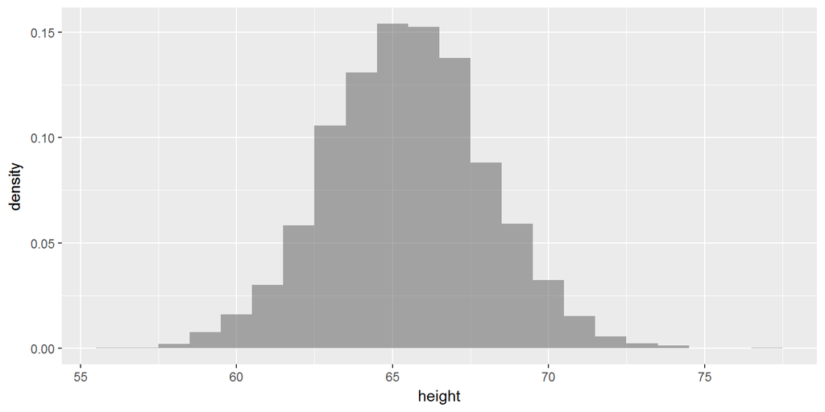

```r
h1 + geom_histogram(aes(y = ..density..), binwidth = 1, alpha = 0.5)
```

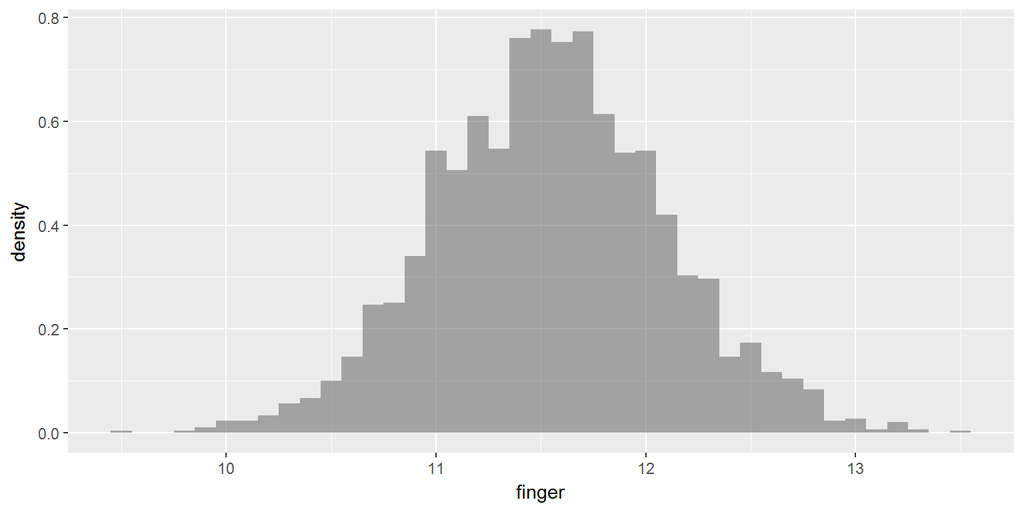

```r
f1 + geom_histogram(aes(y = ..density..), binwidth = 0.1, alpha = 0.5)
```

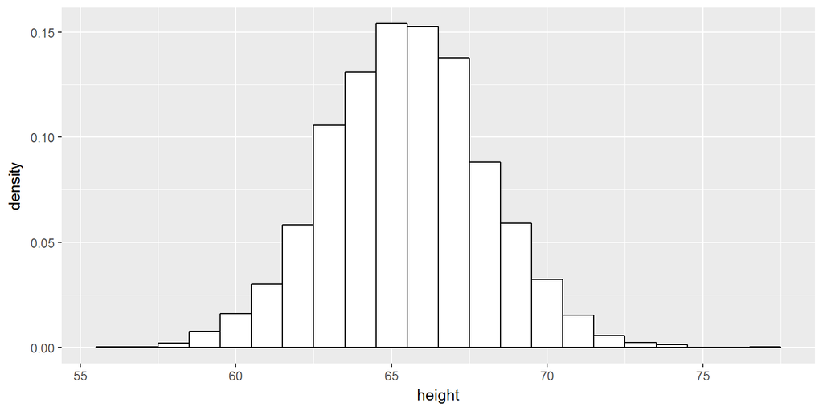

```r
(g.h.1 <- h1 +
    geom_histogram(aes(y = ..density..),
                   binwidth = 1,
                   fill = "white",
                   colour = "black"))
```

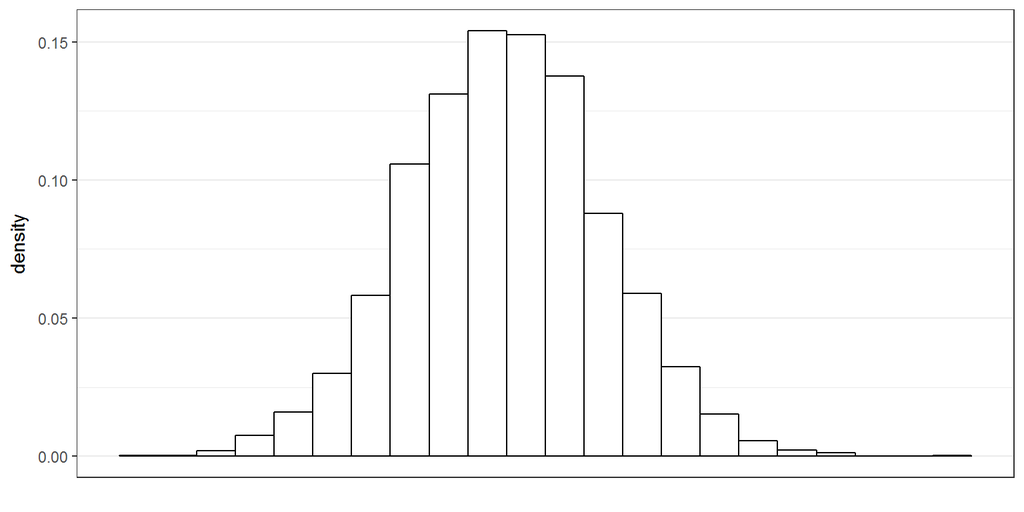

```r
(g.h <- g.h.1 +
    theme_bw() +
    scale_x_continuous(name = "", breaks = NULL))
```

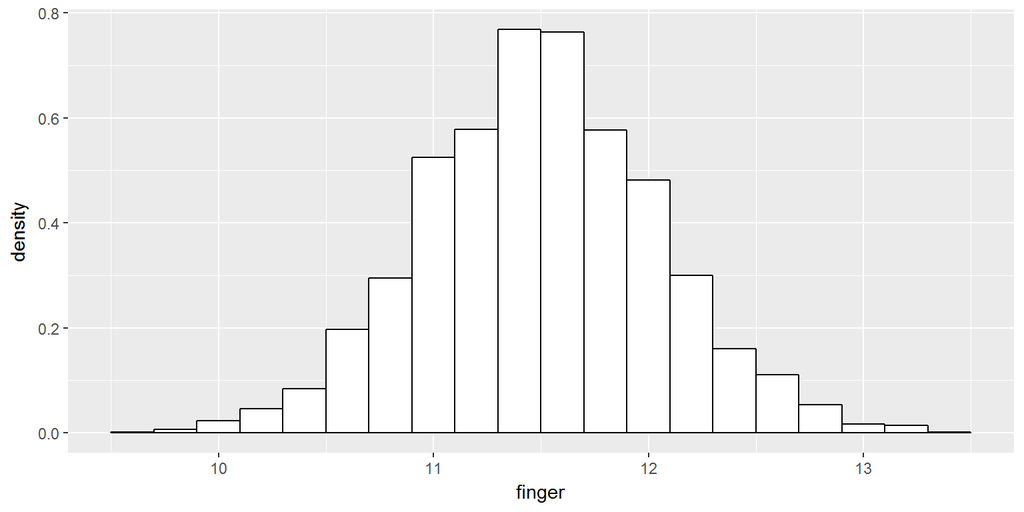

```r
(g.f.1 <- f1 +
    geom_histogram(aes(y = ..density..),
                   binwidth = 0.2,
                   fill = "white",
                   colour = "black"))
```

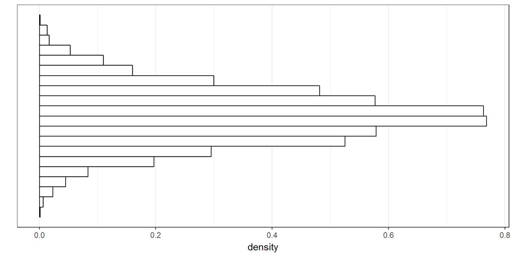

```r
(g.f <- g.f.1 +
    theme_bw() +
    scale_x_continuous(name = "", breaks = NULL) +
    coord_flip())
```

### 평균 위치를 화살표로 나타내려면

```r
library(grid)
(mean.finger <- crimtab.stat[, 1][[1]])
```

```
## [1] 11.54737
```

```r
(sd.finger <- crimtab.stat[, 1][[2]])
```

```
## [1] 0.5487137
```

```r
(mean.height <- crimtab.stat[, 2][[1]])
```

```
## [1] 65.473
```

```r
(sd.height <- crimtab.stat[, 2][[2]])
```

```
## [1] 2.557757
```

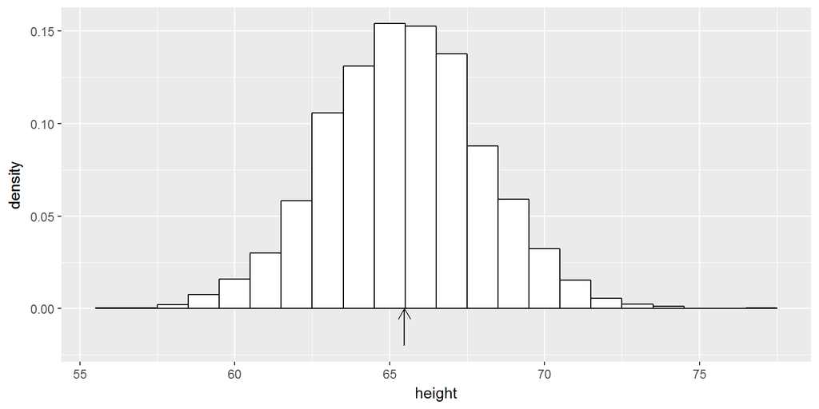

```r
x.finger <- seq(9.5, 13.5, length.out = 3000)
y.finger <- dnorm(x.finger, mean = mean.finger, sd = sd.finger)
x.height <- seq(56, 77, length.out = 3000)
y.height <- dnorm(x.height, mean = mean.height, sd = sd.height)
(g.h.2 <- g.h.1 +
    annotate("segment",
             x = mean.height,
             xend = mean.height,
             y = -0.02,
             yend = 0,
             arrow = arrow(length = unit(0.3, "cm"))))
```

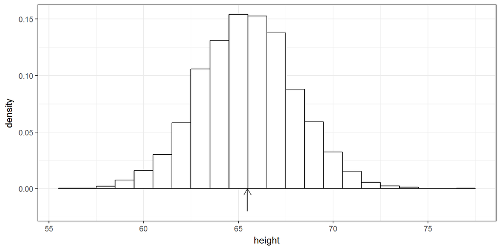

```r
(g.h.3 <- g.h.2 +
    theme_bw())
```

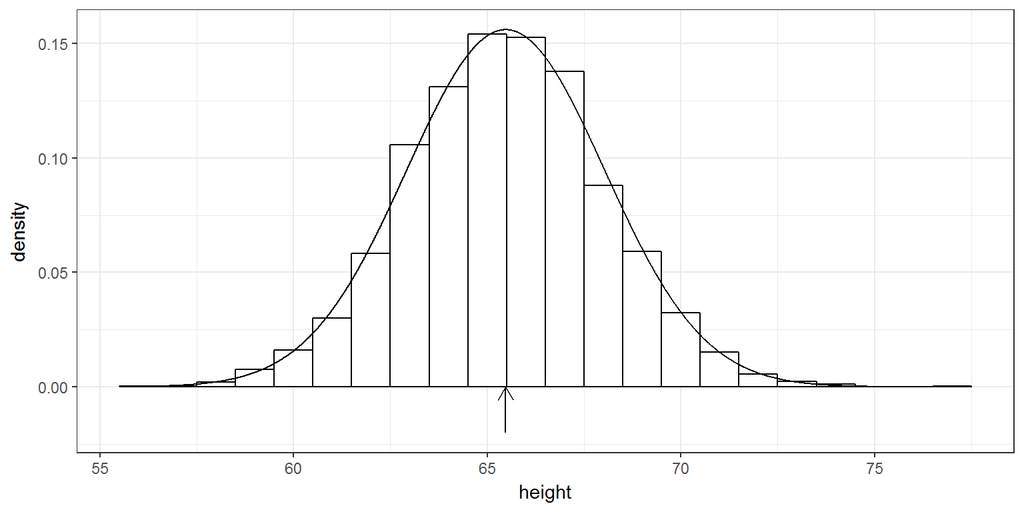

```r
(g.h.4 <- g.h.3 +
    geom_line(aes(x = x.height, y = y.height)))
```

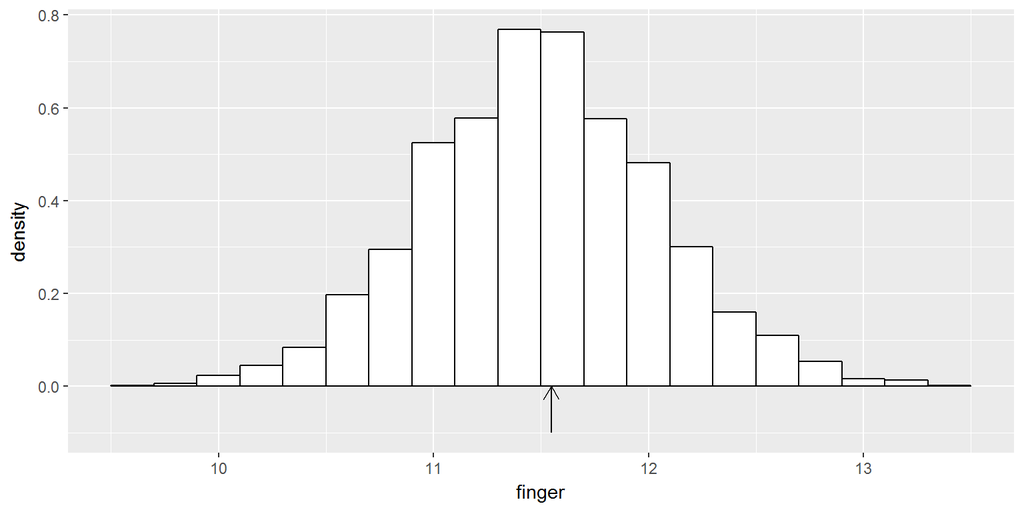

```r
(g.f.2 <- g.f.1 +
    annotate("segment",
             x = mean.finger,
             xend = mean.finger,
             y = -0.1,
             yend = 0,
             arrow = arrow(length = unit(0.3, "cm"))))
```

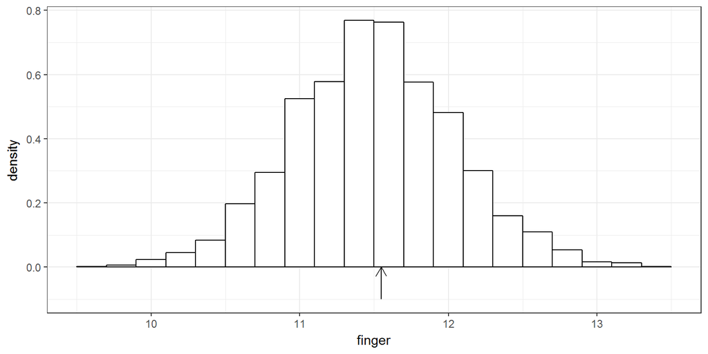

```r
(g.f.3 <- g.f.2 +
    theme_bw())
```

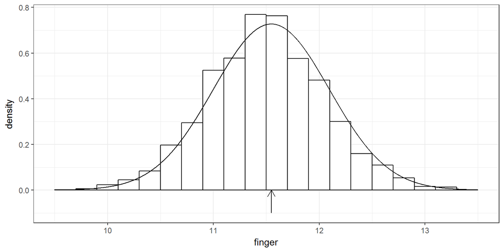

```r
(g.f.4 <- g.f.3 +
    geom_line(aes(x = x.finger, y = y.finger)))
```

### 산점도와 히스토그램 함께 배열하기

`grid` 및 `gridExtra` 패키지와 함께 `blank` Grob 설정이 핵심. `grid.arrange` 사용법에 유의.

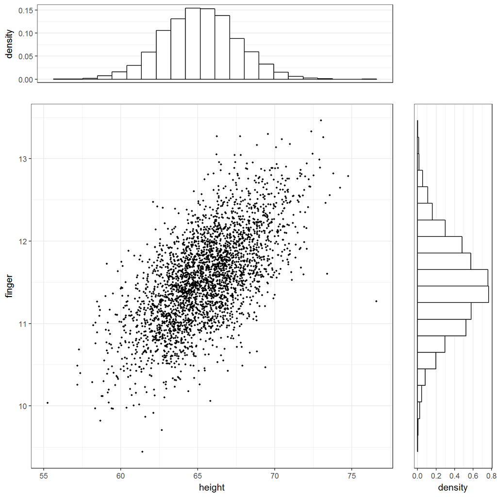

```r
library(gridExtra)
blank <- grid.rect(gp = gpar(col = "white"), draw = FALSE)
grid.arrange(g.h, blank, g3, g.f, ncol = 2, widths = c(4, 1), heights = c(1, 4))
```

### Data 갈무리

```r
save.image(file="./crimtab_ggplot.RData")
# cor(crimtab.2.long[,1], crimtab.2.long[,2])
```